# RepDataProject1

Rob Keefe

July 24, 2016

# Reproducable research project 1

The purpose of this project is to load raw data from a piece of wearable technology, clean this data, and use it to answer certain questions posed in the assignment.

## Loading and processing the data

The raw data is extracted from the github repository and placed as a .csv file in the working directory. The following code loads the data into a useable format. No pre-processing is required at this stage.

```r
setwd("C:/Users/Rob/Dropbox/R Course/ReprodDataProj1")
data <- read.csv('activity.csv')
```

## What is mean total number of steps taken per day?

We will use the dplyr library to aggregate the data by day. This aggregated data, stored in the dataframe daily_steps, is used to generate a histogram of the daily step counts.

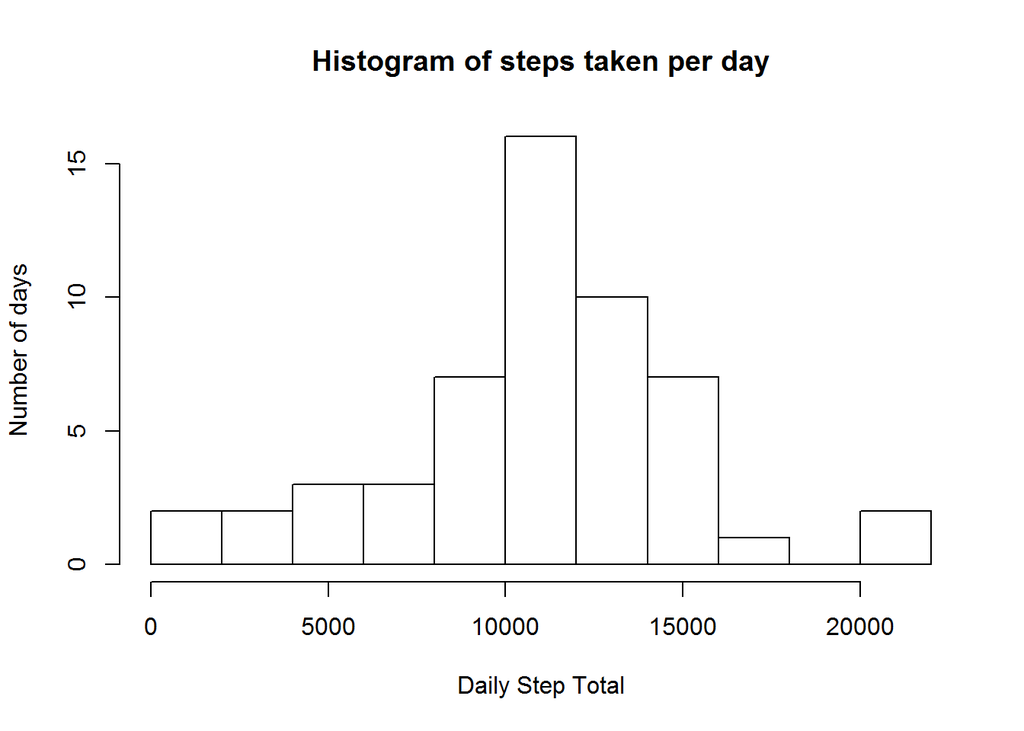

```r
suppressMessages(suppressWarnings(library(dplyr)))
daily_steps <- data %>%
  group_by(date) %>%
  summarize(total.steps = sum(steps))


hist(daily_steps$total.steps,
     breaks= 8,
     main = "Histogram of steps taken per day",
     xlab = 'Daily Step Total',
     ylab = 'Number of days')
```

We can use this dataframe to obtain the average and median daily step counts.

```r
mean_daily_steps <- mean(daily_steps$total.steps, na.rm = T)
mean_daily_steps
```

```
## [1] 10766.19
```

```r
meadian_daily_steps <- median(daily_steps$total.steps, na.rm = T)
meadian_daily_steps
```

```
## [1] 10765
```

## What is the average daily activity pattern?

We use dplyr again to average the step counts by interval across all days. This is saved in the dataframe int_steps. This average is plotted against intervals.

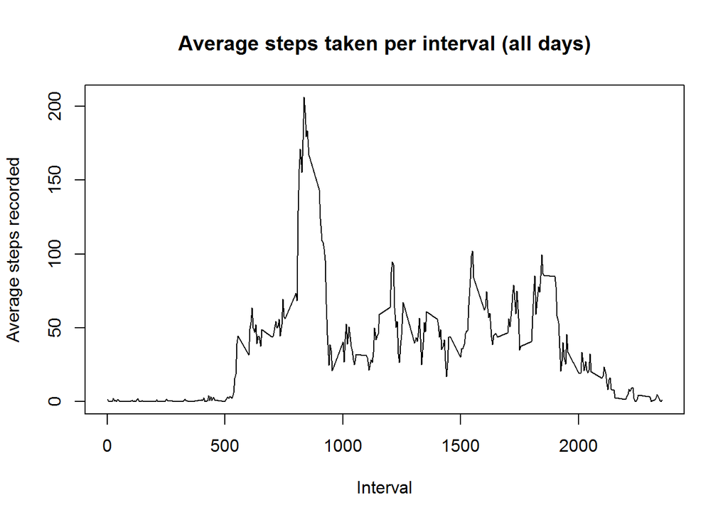

```r
int_steps <- data %>%
  group_by(interval) %>%
  summarize(avg.steps = mean(steps, na.rm = T))

plot(int_steps$interval,int_steps$avg.steps,
     type = 'l',
     main = 'Average steps taken per interval (all days)',
     xlab = 'Interval',
     ylab = 'Average steps recorded')
```

To obtain the interval containing the max number of steps, we sort the int_steps dataframe in decreasing order and look at the first entry.

```r
max_steps <- int_steps[order(-int_steps$avg.steps),]
max_steps[1,]
```

```
## Source: local data frame [1 x 2]
##
##   interval avg.steps
##      (int)     (dbl)
## 1      835  206.1698
```

## Imputing missing values

To calculate the number of NA’s in the steps column we use the in.na function

```r
sum(is.na(data$steps))
```

```
## [1] 2304
```

We will use the strategy of replacing the NA’s with the average (across all days) of the number of steps in that specific interval. Note that this number is contained in the int_steps dataframe.

To do this we will first duplicate our data as data1. Then we will iterate through this dataset. When we find an NA value in the step column we will replace it with the entry in the int_steps dataframe matching the interval of the NA value.

```r
data1 <- data

for (i in 1:NROW(data1)) {

  if (is.na(data1[i,1])) {

    data1[i,1] <- int_steps[ which(int_steps$interval == data1[i,3]),2]
  }
}
```

The dataframe data1 now has all the NA’s replaced with average values for the intervals in question. Using the same method we used previously we can check the mean and median steps and step histogram to see what changes have taken place.

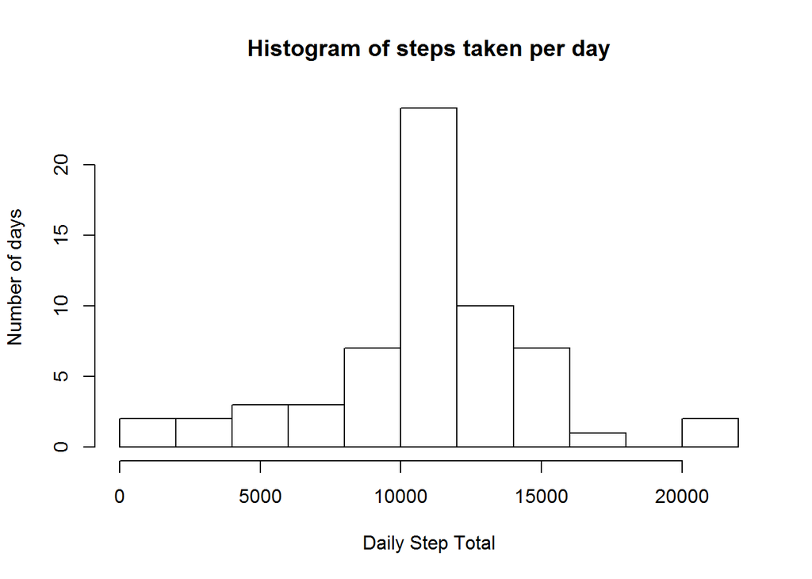

```r
daily_steps1 <- data1 %>%
  group_by(date) %>%
  summarize(total.steps = sum(steps))


hist(daily_steps1$total.steps,
     breaks= 8,
     main = "Histogram of steps taken per day",
     xlab = 'Daily Step Total',
     ylab = 'Number of days')
```

```r
mean_daily_steps1 <- mean(daily_steps1$total.steps, na.rm = T)
mean_daily_steps1
```

```
## [1] 10766.19
```

```r
median_daily_steps1 <- median(daily_steps1$total.steps, na.rm = T)
median_daily_steps1
```

```
## [1] 10766.19
```

## Are there differences in activity patterns between weekdays and weekends?

Finally we will analyze the differences in step patterns between weekdays and weekends. To perform this analysis we need to tag certain entries in the step data as occuring on a weekend and the rest on a weekday.

```r
data1$dtg <- as.Date(as.character(data1$date),'%Y-%m-%d')
data1$dow <- weekdays(data1$dtg)
data1$weekend <- NA
```

To tag a given day as weekend or weekday we will create a new function is_weekend which takes as its argument, a date and returns either “Weekend” of “Weekday”

```r
is_weekend  <- function(dtg) {

  ### Takes a date and returns either Weekday or Weekend as appropriate
  dow <- weekdays(dtg)

  result <- "Weekday"
  if (dow == "Saturday") result <- "Weekend"
  if (dow == "Sunday") result <- "Weekend"

  result

}
```

Now we can iterate through data1 and tag the days as either weekend or weekday

```r
for (i in 1:NROW(data1)) {

   data1[i,6] <- is_weekend(data1[i,4])


 }
```

Now we create tables with the average steps per interval for either weekend days _we or weekdays _wd. We append the correct designation on the $we column of each.

```r
int_steps_wd <- subset(data1, weekend == "Weekday") %>%
  group_by(interval) %>%
  summarize(avg.steps = mean(steps, na.rm = T))

int_steps_we <- subset(data1, weekend == "Weekend") %>%
  group_by(interval) %>%
  summarize(avg.steps = mean(steps, na.rm = T))

int_steps_we$we <- 'Weekend'
int_steps_wd$we <- 'Weekday'
```

Now we combine these two tables into a single dataframe

```r
steps_byday <- rbind(int_steps_wd,int_steps_we)
```

This dataframe is used to create a plot showing the differences in average steps per interval for each day type

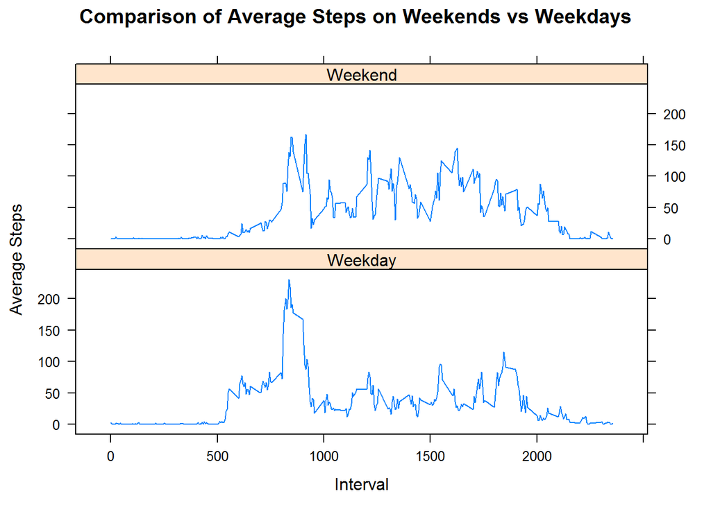

```r
library(lattice)

xyplot(avg.steps ~ interval | we, steps_byday,
       type = 'l',
       layout = c(1,2),
       xlab = "Interval",
       ylab = "Average Steps",
       main = "Comparison of Average Steps on Weekends vs Weekdays"
       )
```